# The market of Electric Vehicles in Europe - a python project

### Author: Pietro Tegon

### The market of EVs in Europe: the evoultion from 2013

Electric vehicles (EVs) have a fascinating history that stretches back to the 1800s. In Europe, early inventors like Hungary’s Ányos Jedlik, who made one of the first electric motors in 1828, and England’s Thomas Parker, who built practical electric cars in the 1880s, were key players in getting the EV ball rolling. Although EVs were initially popular, they lost out to gasoline-powered cars as those became cheaper and more efficient, thanks largely to Henry Ford’s assembly line. Fast forward to today, and the scene has changed dramatically. With rising environmental concerns and significant advances in battery technology, EVs are making a strong comeback.

This surge is powered by strict emissions regulations and substantial government incentives, all aimed at promoting greener transportation options. Initially driven by early adopters and environmental policies, the EV market has rapidly expanded, especially in Europe, boosted by advancements in technology, increasing consumer awareness, and robust governmental incentives. Countries such as Germany, France, and the Netherlands have led the charge, contributing to a substantial rise in EV sales and stock. Infrastructure development, particularly charging points, has further facilitated this growth.

As the industry evolves, the focus is shifting towards improving EV stock share, optimizing the ratio of EVs to charging points, and sustaining the momentum of sales growth. The European Union has set a very ambitious objective in this direction: zero CO2 emissions for new passenger cars and light commercial vehicles in 2035. This notebook explores trends and forecasts about future developments in the European EV landscape by analizing data collected from the IEA (International Energy Agency).

### Research questions

The questions that will constitute the guidelines which will be followed throughout the notebook are:

- During the years, which are the countries that led the market (in sales and stock) of EVs?
- Which are the countries with the best stock ratio for EVs (the countries that have the most electric vehicles compared to the normal ones)?
- Are the various categories of the data correlated? In what way?
- How has the market evolved in the years? Have the sales and the stock increased?

### Project overview and methodology

- Part 1: Installing necessary modules
- Part 2: Data cleaning
- Part 3: Data combining and reshaping
- Part 4: Data analisys and visualization
- Part 5: Forecasting

The data selected will be functional to the answers to the research questions. The method will be quite empirical: the analysis and interpretation of the data will be the basis of the answers. The project is divided in five parts to make the notebook the clearer and easier to read as possible, and include commented code and markdowns that explains the reason behind every step and its result.

## Part 1 - Installing and importing necessary libraries

```python
# pip install matplotlib seaborn
```

```python
# pip install geopandas
```

```python
# pip install statsmodels
```

```python
import pandas as pd # Data manipulation and analysis library

import numpy as np # Numerical computing library

import matplotlib.pyplot as plt # Plotting library

import seaborn as sns # Statistical data visualization library (built on top of matplotlib)

import geopandas as gpd # Geographic data analysis library (works with pandas for geospatial data)

import ipywidgets as widgets

from ipywidgets import widgets, interact # Interactive widgets library for Jupyter Notebooks

from IPython.display import display # For displaying content in Jupyter Notebooks

from statsmodels.tsa.arima.model import ARIMA # Autoregressive integrated moving average: statistical analysis model that uses time series data
                                              # to either better understand the data set or to predict future trends.
import warnings
warnings.filterwarnings('ignore') # This suppresses unwanted warnings
```

Now that all the necessary libraries have been installed and imported, all the tools for data analysis, manipulation, visualisazion and forecasting are available.

## Part 2 - Data cleaning

The datasets which the work is based on are two.

### First dataset

```python
sales_stock = pd.read_csv('IEA-EV-dataEV salesHistoricalCars.csv')

print(sales_stock[:10].to_string()) #[:10] is used to make only the first ten rows show up
                                    # the method .to_string() is used to make all the rows show up on the same line
```

```
      region    category       parameter  mode powertrain  year      unit      value
0  Australia  Historical  EV sales share  Cars         EV  2011   percent    0.00650
1  Australia  Historical  EV stock share  Cars         EV  2011   percent    0.00039
2  Australia  Historical        EV sales  Cars        BEV  2011  Vehicles   49.00000
3  Australia  Historical        EV stock  Cars        BEV  2011  Vehicles   49.00000
4  Australia  Historical        EV stock  Cars        BEV  2012  Vehicles  220.00000
5  Australia  Historical        EV sales  Cars        BEV  2012  Vehicles  170.00000
6  Australia  Historical  EV stock share  Cars         EV  2012   percent    0.00240
7  Australia  Historical  EV sales share  Cars         EV  2012   percent    0.03000
8  Australia  Historical        EV stock  Cars       PHEV  2012  Vehicles   80.00000
9  Australia  Historical        EV sales  Cars       PHEV  2012  Vehicles   80.00000
```

This dataset, which can be found on the IEA website, contains not only information about stock and sales of electric vehicles, but also stock share and sales share. All of these categories are interesting, but separating them and combining them in other ways might make the data more clear and useful. Morover, the research is focused on countries that belong to the EU; data cleaning is needed for the data to be clearer and signicative.

```python
eu_countries = ["Austria", "Belgium", "Bulgaria", "Croatia", "Cyprus", "Czech Republic", "Denmark", "Estonia", "Finland", "France", "Germany", "Greece", "Hungary", "Ireland",
                "Italy", "Latvia",  "Lithuania", "Luxembourg", "Malta", "Netherlands", "Poland", "Portugal", "Romania", "Slovakia", "Slovenia", "Spain", "Sweden"]
# This is a list of all the countries in the EU

eu_data_ssp = sales_stock[sales_stock['region'].isin(eu_countries)] #.isin() method is used to select only the countries that are in the list

eu_data_sales= eu_data_ssp[eu_data_ssp['parameter']=='EV sales'] # In this first cleaning process only the elements with value in the column 'parameter' equal to 'EV sales'
eu_sales= eu_data_sales[eu_data_sales['powertrain'] != 'FCEV'] # We can exclude FCEV (hydrogen powered cars) because they are very rare and are insignificant
                                                               # compared to the rest of electric vehicles


summed_sales = eu_sales.groupby(['region', 'year'])['value'].sum().reset_index() # This groups EV, BEV and PHEV vehicles and sums their sales to obtain just one value per year

summed_sales.columns = ['region', 'year', 'Total EV Sales'] # The only significant columns are these three: we had only historical data, only one parameter selcted, only one mode
                                                            # and unit: vehicle for all rows.
                                                            #The columns have also been switched and renamed

print(summed_sales[:15])
```

```
     region  year  Total EV Sales
0   Austria  2013           650.0
1   Austria  2014          1700.0
2   Austria  2015          2800.0
3   Austria  2016          5000.0
4   Austria  2017          7100.0
5   Austria  2018          9100.0
6   Austria  2019         11500.0
7   Austria  2020         23600.0
8   Austria  2021         48000.0
9   Austria  2022         47000.0
10  Austria  2023         65000.0
11  Belgium  2010            56.0
12  Belgium  2011           296.0
13  Belgium  2012           910.0
14  Belgium  2013           560.0
```

eu_data_ssp_new can be used as a starting point, but this time the stock values will be selected. The process is the same as the one for sales.

```python
eu_data_stock= eu_data_ssp[eu_data_ssp['parameter']=='EV stock']
eu_stock = eu_data_stock[eu_data_stock['powertrain']!='FCEV']

summed_stock = eu_stock.groupby(['region', 'year'])['value'].sum().reset_index()

summed_stock.columns = ['region', 'year', 'Total EV Stock']
print(summed_stock[:15])
```

```
     region  year  Total EV Stock
0   Austria  2010           350.0
1   Austria  2011           990.0
2   Austria  2012          1540.0
3   Austria  2013          2510.0
4   Austria  2014          4180.0
5   Austria  2015          6500.0
6   Austria  2016         11400.0
7   Austria  2017         18900.0
8   Austria  2018         26700.0
9   Austria  2019         38000.0
10  Austria  2020         60000.0
11  Austria  2021        106000.0
12  Austria  2022        152000.0
13  Austria  2023        221000.0
14  Belgium  2010            70.0
```

The same can be done for EV Stock Share.

```python
eu_data_share= eu_data_ssp[eu_data_ssp['parameter']=='EV stock share']
eu_share = eu_data_share[eu_data_share['powertrain']!='FCEV']

summed_share = eu_share.groupby(['region', 'year'])['value'].sum().reset_index()

summed_share.columns = ['region', 'year', 'EV Stock Share']
print(summed_share[:15])
```

```
     region  year  EV Stock Share
0   Austria  2010          0.0079
1   Austria  2011          0.0220
2   Austria  2012          0.0330
3   Austria  2013          0.0530
4   Austria  2014          0.0890
5   Austria  2015          0.1400
6   Austria  2016          0.2400
7   Austria  2017          0.3800
8   Austria  2018          0.5300
9   Austria  2019          0.7500
10  Austria  2020          1.2000
11  Austria  2021          2.1000
12  Austria  2022          3.0000
13  Austria  2023          4.4000
14  Belgium  2010          0.0013
```

### Second dataset

This second dataset, which can be found on the IEA website as well, has the same column names as the previous one, but this time it is about charging points. They're distinct in fast and slow, but only one value per year is needed and it will be the sum of slow and fast charging points for that year in each country.

```python
cp = pd.read_csv('IEA-EV-dataEV charging pointsHistoricalEV.csv')
print(cp[:15].to_string())
```

```
       region    category           parameter mode               powertrain  year             unit   value
0   Australia  Historical  EV charging points   EV  Publicly available fast  2017  charging points    40.0
1   Australia  Historical  EV charging points   EV  Publicly available slow  2017  charging points   440.0
2   Australia  Historical  EV charging points   EV  Publicly available fast  2018  charging points    61.0
3   Australia  Historical  EV charging points   EV  Publicly available slow  2018  charging points   670.0
4   Australia  Historical  EV charging points   EV  Publicly available slow  2019  charging points  1700.0
5   Australia  Historical  EV charging points   EV  Publicly available slow  2020  charging points  2300.0
6   Australia  Historical  EV charging points   EV  Publicly available fast  2021  charging points   320.0
7   Australia  Historical  EV charging points   EV  Publicly available slow  2021  charging points  2000.0
8   Australia  Historical  EV charging points   EV  Publicly available fast  2022  charging points   470.0
9   Australia  Historical  EV charging points   EV  Publicly available slow  2022  charging points  2100.0
10  Australia  Historical  EV charging points   EV  Publicly available fast  2023  charging points   660.0
11  Australia  Historical  EV charging points   EV  Publicly available slow  2023  charging points  2100.0
12    Austria  Historical  EV charging points   EV  Publicly available fast  2011  charging points     0.1
13    Austria  Historical  EV charging points   EV  Publicly available slow  2011  charging points     0.1
14    Austria  Historical  EV charging points   EV  Publicly available fast  2012  charging points     0.1
```

```python
eu_cp = cp[cp['region'].isin(eu_countries)]
eu_cp_new = eu_cp.drop('category', axis=1) # Category isn't needed because it's Historical for every row.

eu_cp_new['value'] = eu_cp_new['value'].round(0) # There are some decimals, but there can't be 0.1 charging points; since it's either 0 or 1,
                                                 # the value will be rounded to 0 decimal places.

summed_cp = eu_cp_new.groupby(['region', 'year'])['value'].sum().reset_index() # The column value will have the sum of fast and slow charging points for each year.

summed_cp.columns = ['region', 'year', 'Total Charging Points'] # This sets the new column names and selects them.

print(summed_cp[:15])
```

```
     region  year  Total Charging Points
0   Austria  2011                    0.0
1   Austria  2012                    0.0
2   Austria  2013                    0.0
3   Austria  2014                    0.0
4   Austria  2015                    0.0
5   Austria  2016                    0.0
6   Austria  2017                    0.0
7   Austria  2018                    0.0
8   Austria  2019                    0.0
9   Austria  2020                    0.0
10  Austria  2021                10500.0
11  Austria  2022                15600.0
12  Austria  2023                17500.0
13  Belgium  2013                  377.0
14  Belgium  2014                  615.0
```

At the end of part 2, we have four distinct datasets, each with three columns. Each one of them has two columns in common with each other: 'region' and 'year'. Having at least a column in common is a fundamental element of a successful merging, which will be the subject of part 3.

## Part 3 - Data combining and reshaping

### Merging multiple datasets

Since it's not possible (or at least it's much harder) to merge multiple datasets, the datasets will be merged two at a time. The first two will be the dataset with sales and the one with stock. The two datasets are merged on 'region' and 'year' because they are the columns in common.

```python
sales_stock_merged = pd.merge(summed_sales, summed_stock, on=['region', 'year']) # separo e printo ogni step

print(sales_stock_merged)
```

```
      region  year  Total EV Sales  Total EV Stock
0    Austria  2013           650.0          2510.0
1    Austria  2014          1700.0          4180.0
2    Austria  2015          2800.0          6500.0
3    Austria  2016          5000.0         11400.0
4    Austria  2017          7100.0         18900.0
..       ...   ...             ...             ...
164   Sweden  2019         41000.0         97000.0
165   Sweden  2020         94000.0        176000.0
166   Sweden  2021        135000.0        300000.0
167   Sweden  2022        163000.0        440000.0
168   Sweden  2023        171000.0        560000.0

[169 rows x 4 columns]
```

The result is a dataset with the same region and year, but with the two value columns of the two datasets representing Total EV Sales and Total EV Stock. The following step is merging the dataset that has just been obtained with the one with charging points.

```python
sales_stock_cp = pd.merge(sales_stock_merged, summed_cp, on=['region', 'year'])

print(sales_stock_cp)
```

```
      region  year  Total EV Sales  Total EV Stock  Total Charging Points
0    Austria  2013           650.0          2510.0                    0.0
1    Austria  2014          1700.0          4180.0                    0.0
2    Austria  2015          2800.0          6500.0                    0.0
3    Austria  2016          5000.0         11400.0                    0.0
4    Austria  2017          7100.0         18900.0                    0.0
..       ...   ...             ...             ...                    ...
146   Sweden  2019         41000.0         97000.0                 9000.0
147   Sweden  2020         94000.0        176000.0                11200.0
148   Sweden  2021        135000.0        300000.0                13700.0
149   Sweden  2022        163000.0        440000.0                17600.0
150   Sweden  2023        171000.0        560000.0                34500.0

[151 rows x 5 columns]
```

The final step is merging the resukt of the previous step with the dataset with the stock share ratio.

```python
final_sscpp= pd.merge(sales_stock_cp, summed_share, on=['region', 'year']  )
print(final_sscpp[:20].to_string())
```

```
     region  year  Total EV Sales  Total EV Stock  Total Charging Points  EV Stock Share
0   Austria  2013           650.0          2510.0                    0.0           0.053
1   Austria  2014          1700.0          4180.0                    0.0           0.089
2   Austria  2015          2800.0          6500.0                    0.0           0.140
3   Austria  2016          5000.0         11400.0                    0.0           0.240
4   Austria  2017          7100.0         18900.0                    0.0           0.380
5   Austria  2018          9100.0         26700.0                    0.0           0.530
6   Austria  2019         11500.0         38000.0                    0.0           0.750
7   Austria  2020         23600.0         60000.0                    0.0           1.200
8   Austria  2021         48000.0        106000.0                10500.0           2.100
9   Austria  2022         47000.0        152000.0                15600.0           3.000
10  Austria  2023         65000.0        221000.0                17500.0           4.400
11  Belgium  2013           560.0          1790.0                  377.0           0.033
12  Belgium  2014          1950.0          3700.0                  615.0           0.067
13  Belgium  2015          3900.0          7100.0                 1377.0           0.130
14  Belgium  2016          9200.0         16200.0                 1610.0           0.280
15  Belgium  2017         14700.0         30500.0                 1720.0           0.530
16  Belgium  2018         13200.0         44000.0                 2940.0           0.740
17  Belgium  2019         17700.0         60000.0                 6460.0           1.000
18  Belgium  2020         47000.0        105000.0                 8480.0           1.800
19  Belgium  2021         71000.0        172000.0                12790.0           2.900
```

There are still a few interesting parameters that could be obtained from the existing columns.

```python
final_sscpp['EV Stock to Charging Points Ratio'] = final_sscpp['Total EV Stock'] / final_sscpp['Total Charging Points']
print(final_sscpp[:20].to_string())
```

```
     region  year  Total EV Sales  Total EV Stock  Total Charging Points  EV Stock Share  EV Stock to Charging Points Ratio
0   Austria  2013           650.0          2510.0                    0.0           0.053                                inf
1   Austria  2014          1700.0          4180.0                    0.0           0.089                                inf
2   Austria  2015          2800.0          6500.0                    0.0           0.140                                inf
3   Austria  2016          5000.0         11400.0                    0.0           0.240                                inf
4   Austria  2017          7100.0         18900.0                    0.0           0.380                                inf
5   Austria  2018          9100.0         26700.0                    0.0           0.530                                inf
6   Austria  2019         11500.0         38000.0                    0.0           0.750                                inf
7   Austria  2020         23600.0         60000.0                    0.0           1.200                                inf
8   Austria  2021         48000.0        106000.0                10500.0           2.100                          10.095238
9   Austria  2022         47000.0        152000.0                15600.0           3.000                           9.743590
10  Austria  2023         65000.0        221000.0                17500.0           4.400                          12.628571
11  Belgium  2013           560.0          1790.0                  377.0           0.033                           4.748011
12  Belgium  2014          1950.0          3700.0                  615.0           0.067                           6.016260
13  Belgium  2015          3900.0          7100.0                 1377.0           0.130                           5.156137
14  Belgium  2016          9200.0         16200.0                 1610.0           0.280                          10.062112
15  Belgium  2017         14700.0         30500.0                 1720.0           0.530                          17.732558
16  Belgium  2018         13200.0         44000.0                 2940.0           0.740                          14.965986
17  Belgium  2019         17700.0         60000.0                 6460.0           1.000                           9.287926
18  Belgium  2020         47000.0        105000.0                 8480.0           1.800                          12.382075
19  Belgium  2021         71000.0        172000.0                12790.0           2.900                          13.448006
```

```python
final_sscpp['EV Sales Growth Rate'] = final_sscpp.groupby('region')['Total EV Sales'].pct_change() * 100

# I have some NaN because it's the first year and can't be compared with anything

print(final_sscpp[:20].to_string())
```

```
     region  year  Total EV Sales  Total EV Stock  Total Charging Points  EV Stock Share  EV Stock to Charging Points Ratio  EV Sales Growth Rate
0   Austria  2013           650.0          2510.0                    0.0           0.053                                inf                   NaN
1   Austria  2014          1700.0          4180.0                    0.0           0.089                                inf            161.538462
2   Austria  2015          2800.0          6500.0                    0.0           0.140                                inf             64.705882
3   Austria  2016          5000.0         11400.0                    0.0           0.240                                inf             78.571429
4   Austria  2017          7100.0         18900.0                    0.0           0.380                                inf             42.000000
5   Austria  2018          9100.0         26700.0                    0.0           0.530                                inf             28.169014
6   Austria  2019         11500.0         38000.0                    0.0           0.750                                inf             26.373626
7   Austria  2020         23600.0         60000.0                    0.0           1.200                                inf            105.217391
8   Austria  2021         48000.0        106000.0                10500.0           2.100                          10.095238            103.389831
9   Austria  2022         47000.0        152000.0                15600.0           3.000                           9.743590             -2.083333
10  Austria  2023         65000.0        221000.0                17500.0           4.400                          12.628571             38.297872
11  Belgium  2013           560.0          1790.0                  377.0           0.033                           4.748011                   NaN
12  Belgium  2014          1950.0          3700.0                  615.0           0.067                           6.016260            248.214286
13  Belgium  2015          3900.0          7100.0                 1377.0           0.130                           5.156137            100.000000
14  Belgium  2016          9200.0         16200.0                 1610.0           0.280                          10.062112            135.897436
15  Belgium  2017         14700.0         30500.0                 1720.0           0.530                          17.732558             59.782609
16  Belgium  2018         13200.0         44000.0                 2940.0           0.740                          14.965986            -10.204082
17  Belgium  2019         17700.0         60000.0                 6460.0           1.000                           9.287926             34.090909
18  Belgium  2020         47000.0        105000.0                 8480.0           1.800                          12.382075            165.536723
19  Belgium  2021         71000.0        172000.0                12790.0           2.900                          13.448006             51.063830
```

There are some NaN values for the new column 'EV Sales Growth Rate', because it calculates the percent change from the previous year. The year 2013 does not have a previous year, and that's why some NaN occur. This can be fixed using .fillna(0), which subsitutes 0s to the NaNs.

```python
final_sscpp['EV Sales Growth Rate'] = final_sscpp['EV Sales Growth Rate'].fillna(0)
print(final_sscpp[:20].to_string())
```

```
     region  year  Total EV Sales  Total EV Stock  Total Charging Points  EV Stock Share  EV Stock to Charging Points Ratio  EV Sales Growth Rate
0   Austria  2013           650.0          2510.0                    0.0           0.053                                inf              0.000000
1   Austria  2014          1700.0          4180.0                    0.0           0.089                                inf            161.538462
2   Austria  2015          2800.0          6500.0                    0.0           0.140                                inf             64.705882
3   Austria  2016          5000.0         11400.0                    0.0           0.240                                inf             78.571429
4   Austria  2017          7100.0         18900.0                    0.0           0.380                                inf             42.000000
5   Austria  2018          9100.0         26700.0                    0.0           0.530                                inf             28.169014
6   Austria  2019         11500.0         38000.0                    0.0           0.750                                inf             26.373626
7   Austria  2020         23600.0         60000.0                    0.0           1.200                                inf            105.217391
8   Austria  2021         48000.0        106000.0                10500.0           2.100                          10.095238            103.389831
9   Austria  2022         47000.0        152000.0                15600.0           3.000                           9.743590             -2.083333
10  Austria  2023         65000.0        221000.0                17500.0           4.400                          12.628571             38.297872
11  Belgium  2013           560.0          1790.0                  377.0           0.033                           4.748011              0.000000
12  Belgium  2014          1950.0          3700.0                  615.0           0.067                           6.016260            248.214286
13  Belgium  2015          3900.0          7100.0                 1377.0           0.130                           5.156137            100.000000
14  Belgium  2016          9200.0         16200.0                 1610.0           0.280                          10.062112            135.897436
15  Belgium  2017         14700.0         30500.0                 1720.0           0.530                          17.732558             59.782609
16  Belgium  2018         13200.0         44000.0                 2940.0           0.740                          14.965986            -10.204082
17  Belgium  2019         17700.0         60000.0                 6460.0           1.000                           9.287926             34.090909
18  Belgium  2020         47000.0        105000.0                 8480.0           1.800                          12.382075            165.536723
19  Belgium  2021         71000.0        172000.0                12790.0           2.900                          13.448006             51.063830
```

Now the dataset is complete and there are a lot of very signicative values. With the help of some libraries for data analisys and visualization the meaning of the data will be clearer: this will be the purpose of step four.

## Part 4 - Data analisys and visualization

### Data analysis

#### Correlation analysis

Correlation analysis is a statistical technique used to assess the strength and direction of the relationship between two variables. It doesn't necessarily determine causation, but helps identify potential connections within the data. Correlation analysis provides a numerical coefficient (between -1 and +1) that indicates the degree of association between two variables.

A higher positive value means a stronger positive correlation (as one variable increases, the other tends to increase as well). On the other hand, a higher negative value indicates a stronger negative correlation (as one variable increases, the other tends to decrease). A value close to zero suggests little to no linear relationship.

```python
correlation_matrix = final_sscpp[['Total EV Sales', 'Total EV Stock', 'Total Charging Points']].corr()

print(correlation_matrix)
```

```
                       Total EV Sales  Total EV Stock  Total Charging Points
Total EV Sales               1.000000        0.956936               0.739016
Total EV Stock               0.956936        1.000000               0.805497
Total Charging Points        0.739016        0.805497               1.000000
```

As the values of the correlation coefficient suggest, all values have strong positive correlations. The weakest one is the one between sales and total charging points; this could be explained by the fact that sales are a value which starts from 0 every year, while total charging points start from the value of the previous year.

#### Overview on the best countries for each category

A dictionary will be used to find out which is the "best" country for each year for each category.

```python
categories = ['Total EV Sales',
    'Total EV Stock',
    'Total Charging Points',
    'EV Stock Share',
    'EV Stock to Charging Points Ratio',
    'EV Sales Growth Rate'] # This is a list of all the columns of the dataset
top_countries = {} # A dictionary is initialized

for category in categories:
    top_countries[category] = final_sscpp.loc[final_sscpp.groupby('year')[category].idxmax()] # The key is the category and the value is the max in the category for each year

lowest_ev_stock_to_cp_ratio = final_sscpp.loc[final_sscpp.groupby('year')['EV Stock to Charging Points Ratio'].idxmin()] # The best in this category is not the one with the highest
                                                                                                                         # value, but with the lowest (ideally the
                                                                                                                         # perfect ratio is 1 charging point per car)
top_countries['EV Stock to Charging Points Ratio'] = lowest_ev_stock_to_cp_ratio

for category, top_df in top_countries.items():
    print(f"Top country for {category}:\n", top_df[['region', 'year', category]], "\n")
```

```
Top country for Total EV Sales:
          region  year  Total EV Sales
92  Netherlands  2010           120.0
93  Netherlands  2011           877.0
45       France  2012          6360.0
95  Netherlands  2013         22600.0
96  Netherlands  2014         14700.0
97  Netherlands  2015         42400.0
49       France  2016         30600.0
62      Germany  2017         54000.0
63      Germany  2018         67000.0
64      Germany  2019        108000.0
65      Germany  2020        390000.0
66      Germany  2021        690000.0
67      Germany  2022        830000.0
```

[output cut: 86 more lines]

Now it's clear, for each category, which is the best country for each year. Netherlands leads Europe for the statistics that consider charging points, and was also a pioneer of the sector of EV, leading almost every statistic in the early years (we also need to consider that less countries are included in data before 2013 because there wasn't a significant amount of vehicles).

In more recent years, countries with bigger economies, like Germany and France, lead Europe for sales and stock. If we take into consideration statistic that don't look at absolute values, but at proportions, smaller countries lead: Denmark and Sweden lead the category 'EV Stock share', while Greece and Poland lead the category 'EV Sales Growth Rate'; this is probably because of a late developement of the sector: now, probably also because of Europe's incentives, these countries have developed in the EV sector in a shorter period.

### Data Visualization

This part of the project requires libraries like seaborn, geopandas, matplotlib.pyplot and IPython.display, which have been imported at the beginning of the project.

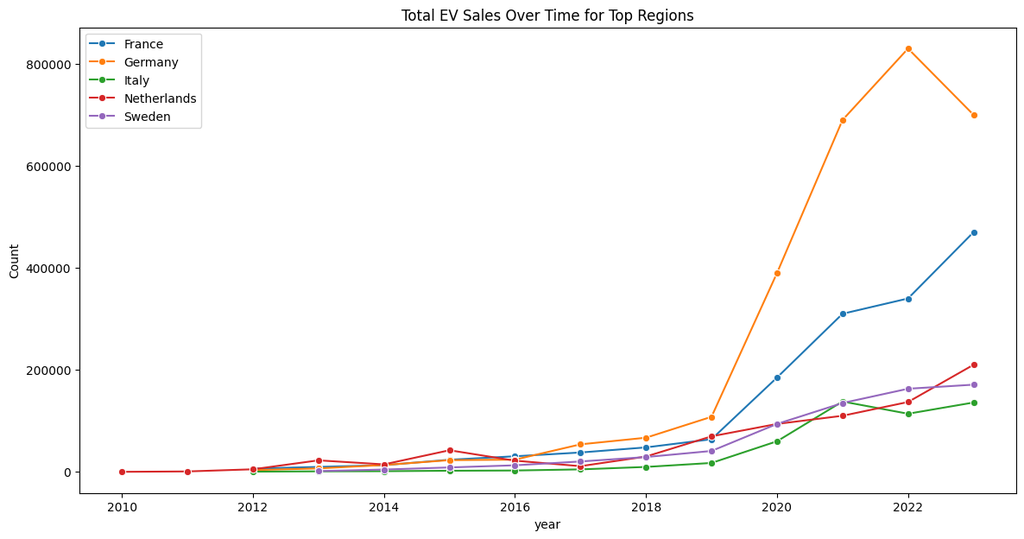

```python
top_regions = final_sscpp[final_sscpp['year'] == 2023].nlargest(5, 'Total EV Stock')['region'] # Taking the top 5 countries for the category (displaying all of them would be confusing)
# Filter the DataFrame to include only the top regions
df_filtered = final_sscpp[final_sscpp['region'].isin(top_regions)] # Taking only the top 5 countries

# Line chart for Total EV Sales and Total EV Stock over time
plt.figure(figsize=(14, 7))
sns.lineplot(data=df_filtered, x='year', y='Total EV Sales', hue='region', marker='o')

plt.title('Total EV Sales Over Time for Top Regions') # Giving the title to the graph
plt.ylabel('Count')
plt.legend(loc='upper left')
plt.show()
```

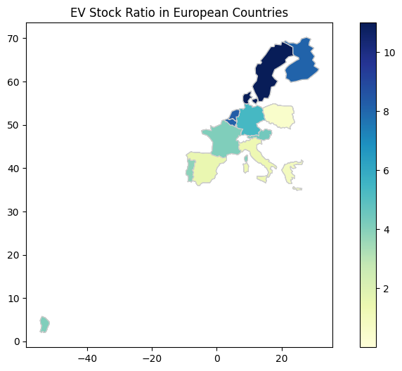

```python
world = gpd.read_file(gpd.datasets.get_path('naturalearth_lowres')) # Download map

europe = world[world['continent'] == 'Europe'] # Filter the world map to include only European countries

europe_ev = europe.merge(pd.DataFrame(final_sscpp), left_on='name', right_on='region', how='left') # Merge the map data with the EV stock ratio data

fig, ax = plt.subplots(1, 1, figsize=(10, 6)) # Plot the map
europe_ev.plot(column='EV Stock Share', cmap='YlGnBu', linewidth=0.8, ax=ax, edgecolor='0.8', legend=True)
ax.set_title('EV Stock Ratio in European Countries')
```

This map is very helpful to visualize the ratio of electric vehicles to normal vehicles. The Northern countries are the ones with the best ratio, with numbers close to 10%, while countries like Italy, Spain and Greece are close to 2%. This shows the difference and disparity between EU countries, despite having common objectives set by EU. Despite leading in sales, Germany and France are not the ones with the best ratio, because they also have more non-electric vehicles.

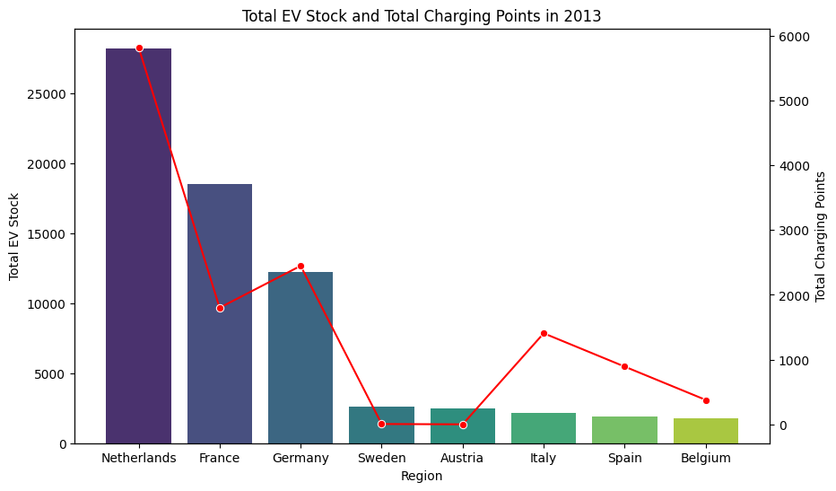

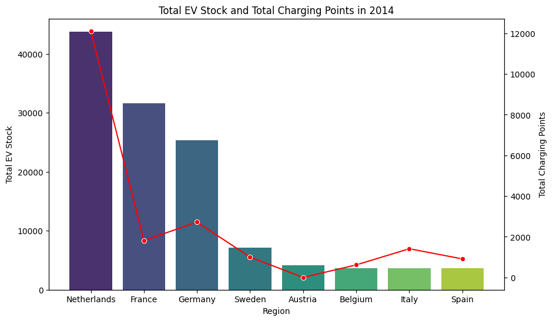

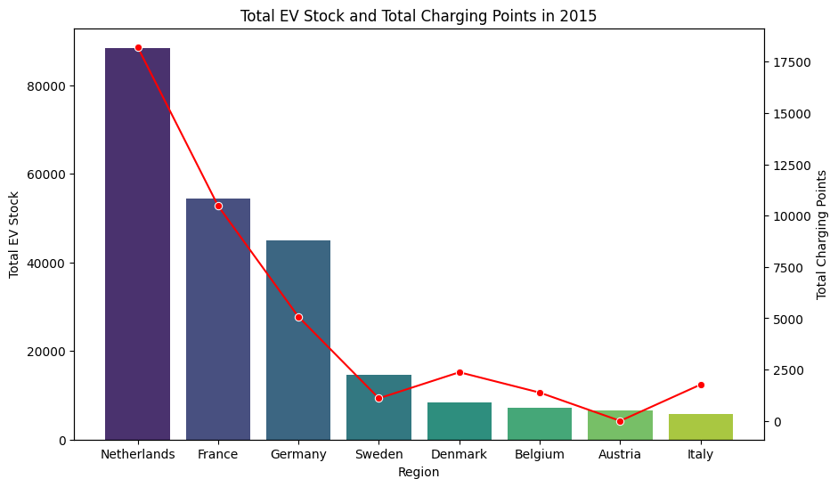

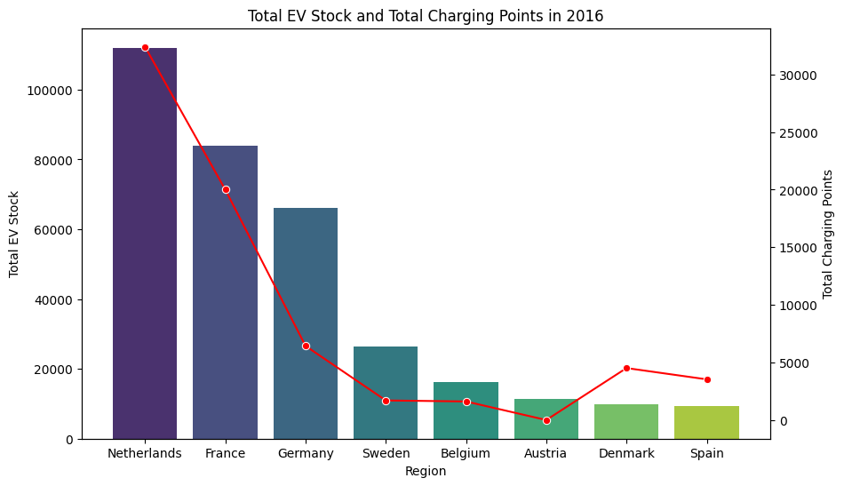

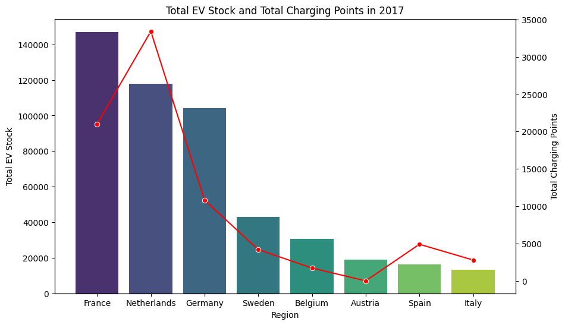

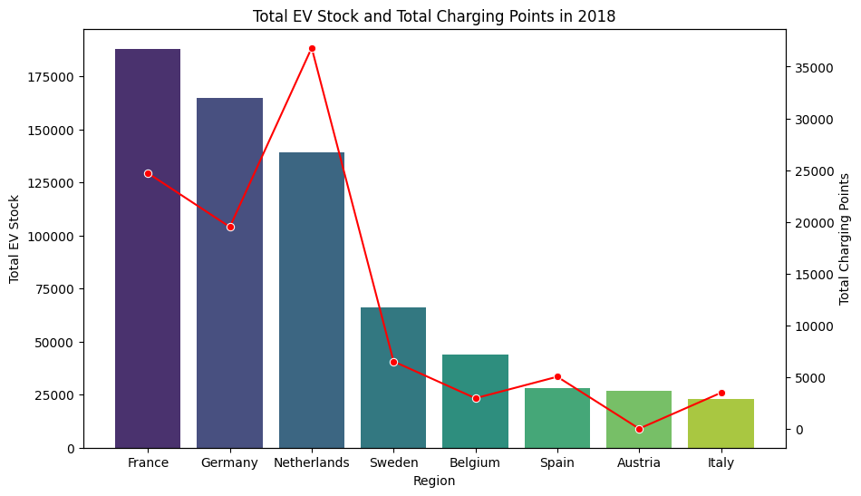

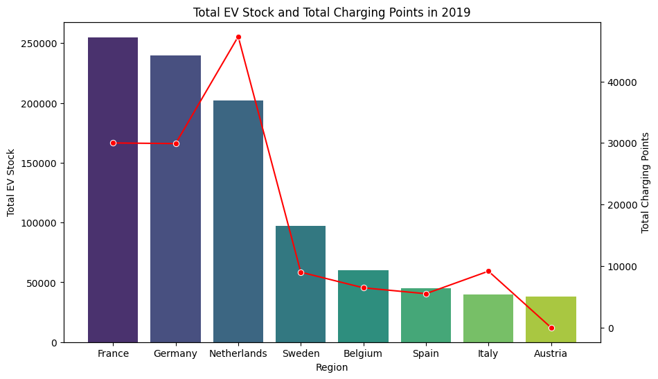

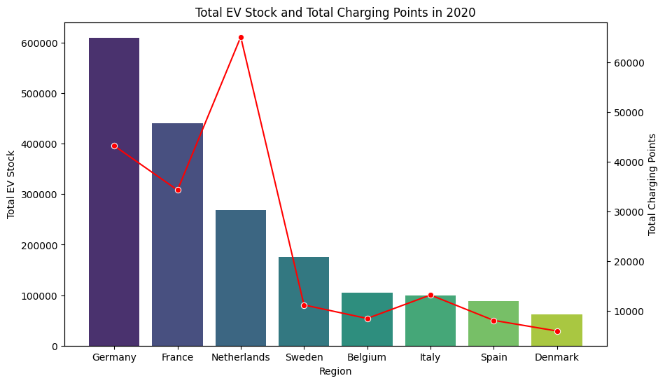

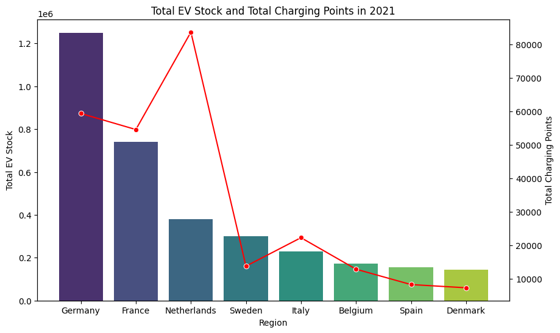

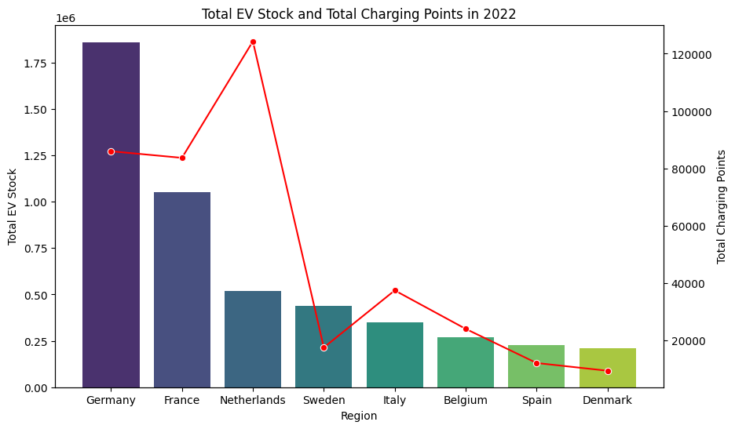

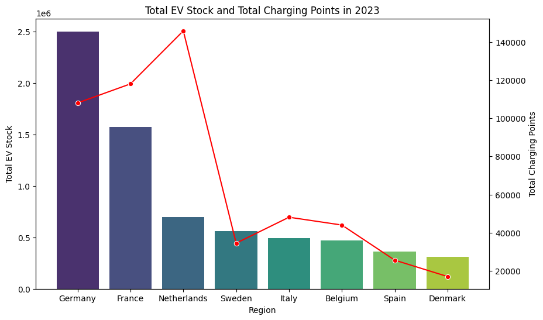

```python
def plot_bar_dual_axis_top_8(year):
    df_year = final_sscpp[final_sscpp['year'] == year]

    # Sort the DataFrame by Total EV Sales and select the top 8 countries
    df_year_sorted = df_year.sort_values(by='Total EV Stock', ascending=False).head(8)

    fig, ax1 = plt.subplots(figsize=(10, 6))

    ax2 = ax1.twinx()

    sns.barplot(data=df_year_sorted, x='region', y='Total EV Stock', palette='viridis', ax=ax1)
    sns.lineplot(data=df_year_sorted, x='region', y='Total Charging Points', color='r', marker='o', ax=ax2)

    ax1.set_title(f'Total EV Stock and Total Charging Points in {year}')
    ax1.set_xlabel('Region')
    ax1.set_ylabel('Total EV Stock')
    ax2.set_ylabel('Total Charging Points')

    plt.show()

#Showing the graph for each year
for i in range(2013,2024):
    plot_bar_dual_axis_top_8(i)
```

This graph shows the relationship between Total EV Stock and Total Charging points. It's important to keep in mind that the scale on the right and the one on the left are different. The correlation between the two categories is clear: even if some countries have a higher ratio than others, the more EVs there are, the more charging points there are. This is an important relationship to consider for the future, because if the quantity of EVs will keep increasing, the charging points will have to do so as well. Countries like the Netherlands are well prepared: they have more charging points than Germany and France with respectively less than a third and less than half electric vehicles. Generally, over time, there was not a significant change in shape of the curve formed by the charging point: this means that they were kept proportionate to the number of vehicles as they were in the first years.

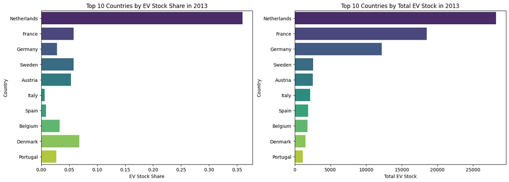

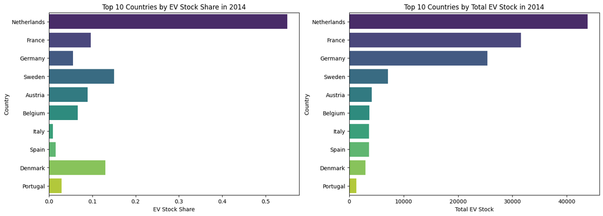

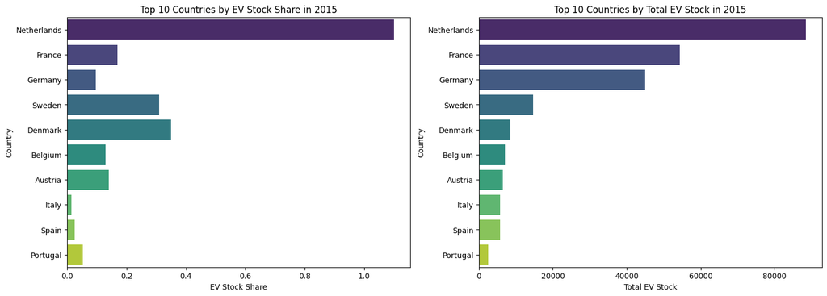

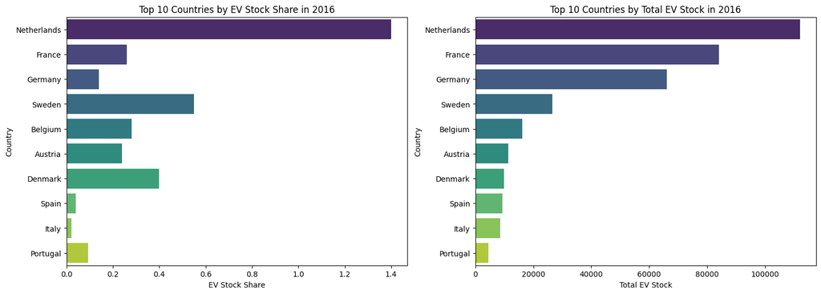

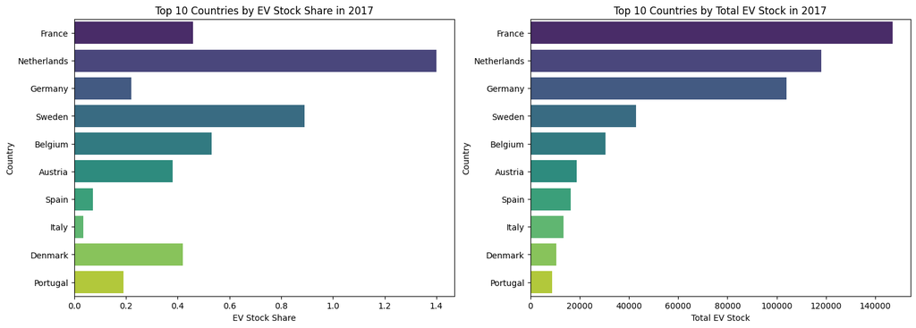

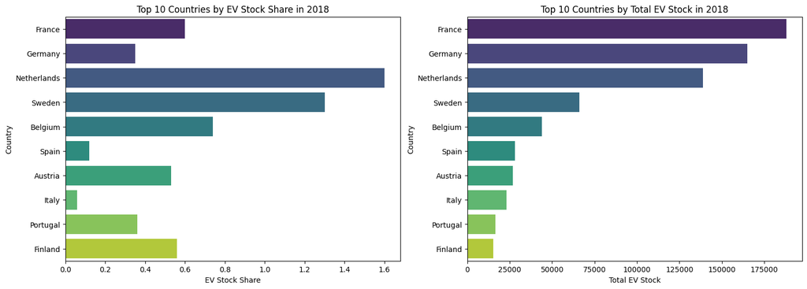

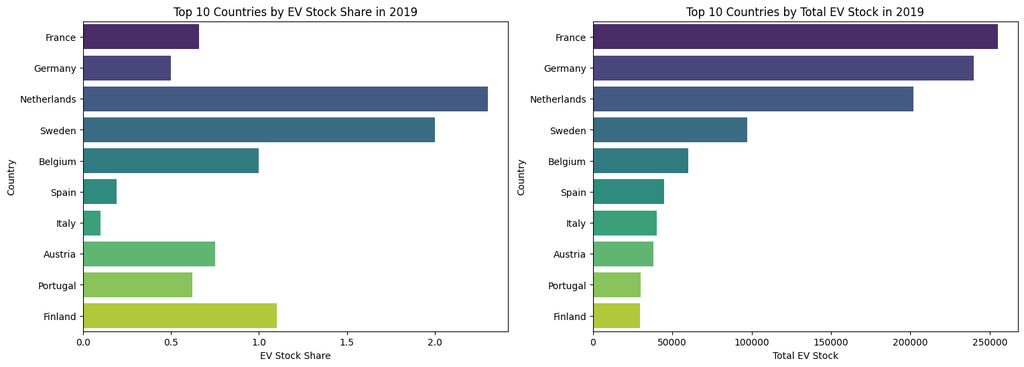

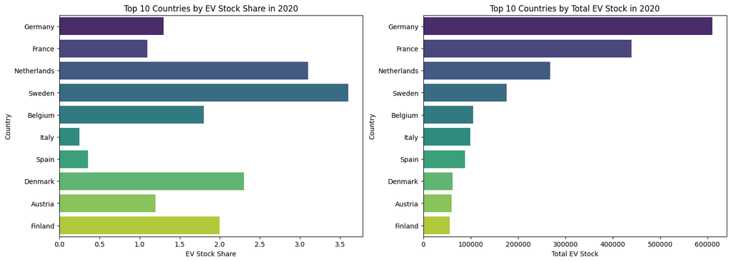

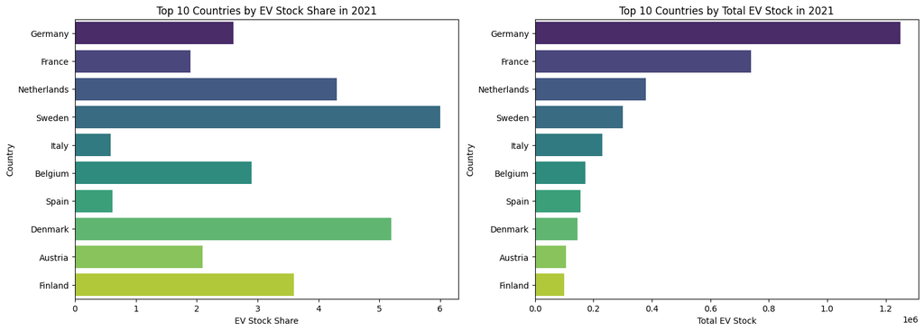

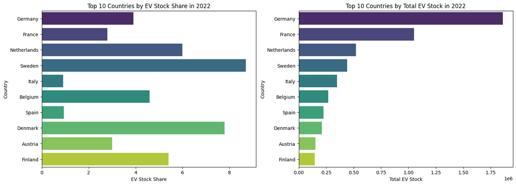

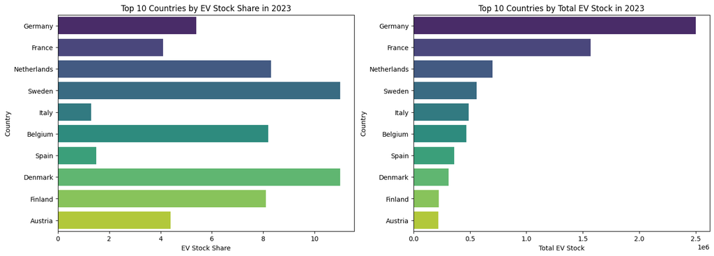

```python
def plot_ev_data(year): # The function allows to place two graphs in the same output, making it easier to see similarities and differences

    # Filtering the DataFrame for the selected year
    df_year = final_sscpp[final_sscpp['year'] == year]

    # Getting the top 10 countries by Total EV Stock
    top_10_stock = df_year.nlargest(10, 'Total EV Stock')

    # Creating the plot
    fig, axes = plt.subplots(1, 2, figsize=(18, 6))

    # Plotting EV Stock Share
    sns.barplot(data=top_10_stock, x='EV Stock Share', y='region', palette='viridis', ax=axes[0])
    axes[0].set_title(f'Top 10 Countries by EV Stock Share in {year}')
    axes[0].set_xlabel('EV Stock Share')
    axes[0].set_ylabel('Country')

    # Plotting Total EV Stock
    sns.barplot(data=top_10_stock, x='Total EV Stock', y='region', palette='viridis', ax=axes[1])
    axes[1].set_title(f'Top 10 Countries by Total EV Stock in {year}')
    axes[1].set_xlabel('Total EV Stock')
    axes[1].set_ylabel('Country')


#Showing the graphs for each year
for i in range(2013,2024):
    plot_ev_data(i)
```

The two graphs make the distinction between stock and stock share very clear. Despite being in lower positions in EV Stock, countries like Finland, Denmark and Sweden have much higher values in Stock Share. During the 10 years taken into consideration, the increase in Stock and Stock share has been significant. In 2013 the top country in Total EV Stock (Netherlands) had about 25000 vehicles. In 2023 Germany, which now leads the category, has about 2.5 million EVs. That's a 100x increase, which is impressive. The stock share has also improved: in 2013 Netherlands, leader of the category, had an EV Stock Share of about 0.35%, while in 2023 Denmark and Sweden have a value above 10%.

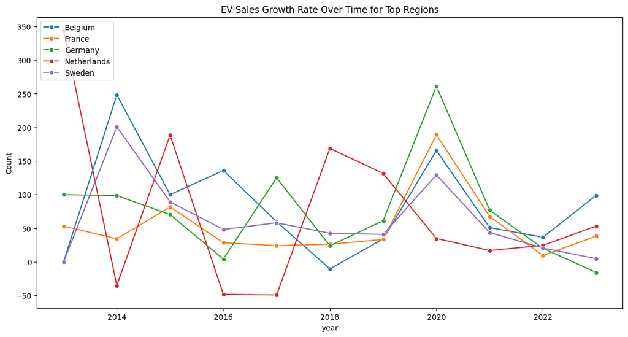

```python
top_regions = final_sscpp[final_sscpp['year'] == 2023].nlargest(5, 'Total EV Sales')['region'] # Taking the top 5 countries for the sales category
                                                                                               # because comparisons with sales are interesting

df_filtered = final_sscpp[final_sscpp['region'].isin(top_regions)] # Taking only the top 5 countries
df_2013= df_filtered[df_filtered['year']>=2013] # Some countries have data that starts from 2010, but 2013 is the first year common to all countries


plt.figure(figsize=(14, 7))
sns.lineplot(data=df_2013, x='year', y='EV Sales Growth Rate', hue='region', marker='o') # Line chart for Total EV Sales and Total EV Stock over time

plt.title('EV Sales Growth Rate Over Time for Top Regions') # Giving the title to the graph
plt.ylabel('Count')
plt.legend(loc='upper left')
plt.show()
```

## Part 5 - Forecasting

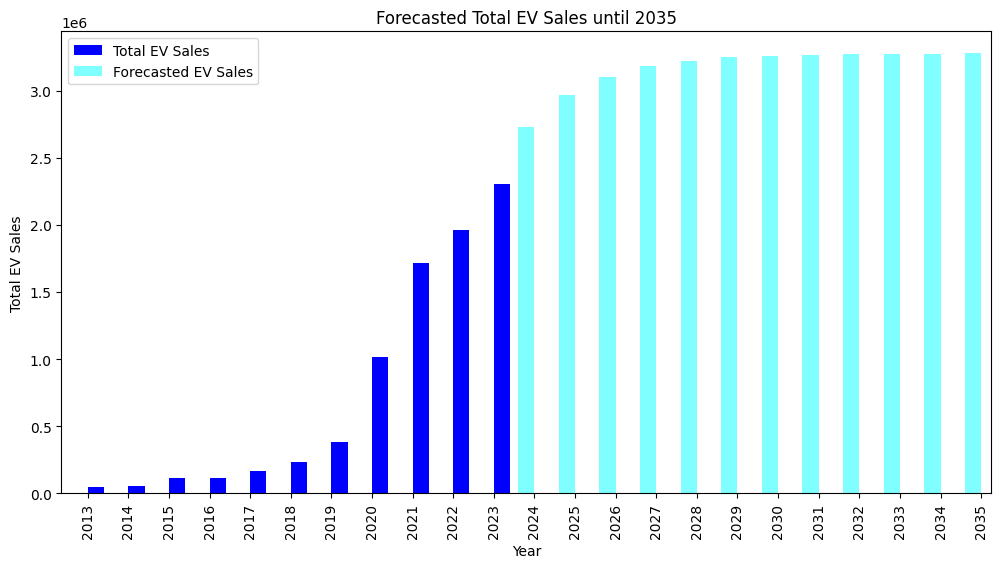

```python
# Filter the dataset for years >= 2013 (some countries have data from 2010, but in the next step a dataframe is going to be created with the sum of
# all sales in a year for each country, and years from 2010 to 2012 would make predictions less reliable)

filtered_df = final_sscpp[final_sscpp['year'] >= 2013]

# Aggregate data by year
df_yearly = filtered_df.groupby('year').agg({
    'Total EV Sales': 'sum',
    'EV Stock Share': 'mean'
}).reset_index()

df_yearly.set_index('year', inplace=True)

# Fit ARIMA model for Total EV Sales
model_sales = ARIMA(df_yearly['Total EV Sales'], order=(1, 1, 1))
model_sales_fit = model_sales.fit()

# Forecast the next years until 2035
forecast_years = list(range(2024, 2036))

# Forecasting for Total EV Sales
forecast_sales = model_sales_fit.get_forecast(steps=len(forecast_years))
forecast_sales_values = forecast_sales.predicted_mean
forecast_sales_ci = forecast_sales.conf_int()

# Create a DataFrame to hold the forecasted values
forecast_df_sales = pd.DataFrame({
    'year': forecast_years,
    'Forecasted EV Sales': forecast_sales_values
})
forecast_df_sales.set_index('year', inplace=True)

# Combine with historical data for plotting
combined_df_sales = pd.concat([df_yearly[['Total EV Sales']], forecast_df_sales])

# Plot the forecasted data for Total EV Sales
fig, ax1 = plt.subplots(figsize=(12, 6))

combined_df_sales['Total EV Sales'].plot(kind='bar', color='blue', ax=ax1, position=0, width=0.4, label='Total EV Sales')
combined_df_sales['Forecasted EV Sales'].plot(kind='bar', color='cyan', ax=ax1, position=1, width=0.4, alpha=0.5, label='Forecasted EV Sales')

# Adding labels and title
ax1.set_ylabel('Total EV Sales')
ax1.set_xlabel('Year')
ax1.set_title('Forecasted Total EV Sales until 2035')
ax1.legend(loc='upper left')

plt.show()
```

The prediction of this model for the years to come is very interesting. The forecasted sales of electric vehicles are expected to keep growing, but at a slower pace each year. The gap between one column and the following one gets smaller at every step. This means that the growth rate will decline and the sales are expected to stabilize at around 3 million units a year. The total of cars sold in Europe in 2023 was more than 12 million; considering that the number might grow in the next eleven years, if the sales of EVs follow the predicted path, they won't be enough for Europe to successfully complete the objective posed for 2035, because the three million EVs sold will only make up for less than a quarter of the demand.

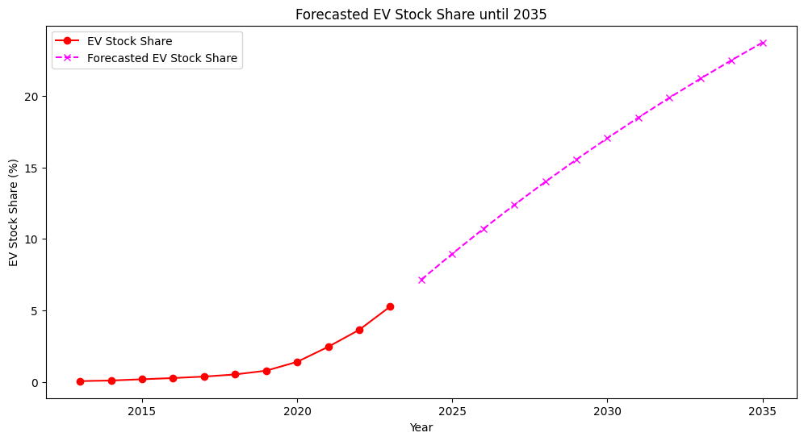

```python
# Fit ARIMA model for EV Stock Share
model_stock_share = ARIMA(df_yearly['EV Stock Share'], order=(1, 1, 1))
model_stock_share_fit = model_stock_share.fit()

# Forecasting for EV Stock Share
forecast_stock_share = model_stock_share_fit.get_forecast(steps=len(forecast_years))
forecast_stock_share_values = forecast_stock_share.predicted_mean
forecast_stock_share_ci = forecast_stock_share.conf_int()

# Create a DataFrame to hold the forecasted values
forecast_df_stock_share = pd.DataFrame({
    'year': forecast_years,
    'Forecasted EV Stock Share': forecast_stock_share_values
})
forecast_df_stock_share.set_index('year', inplace=True)

# Combine with historical data for plotting
combined_df_stock_share = pd.concat([df_yearly[['EV Stock Share']], forecast_df_stock_share])

# Plot the forecasted data for EV Stock Share
fig, ax2 = plt.subplots(figsize=(12, 6))

combined_df_stock_share['EV Stock Share'].plot(kind='line', color='red', marker='o', ax=ax2, label='EV Stock Share')
combined_df_stock_share['Forecasted EV Stock Share'].plot(kind='line', color='magenta', marker='x', ax=ax2, linestyle='--', label='Forecasted EV Stock Share')

# Adding labels and title
ax2.set_ylabel('EV Stock Share (%)')
ax2.set_xlabel('Year')
ax2.set_title('Forecasted EV Stock Share until 2035')
ax2.legend(loc='upper left')

plt.show()
```

This graph shows the forecast of the EV Stock Share. The growth is steady and, according to the prediction, by 2035 we should reach a stock share of almost 25%. This means that 1 in 4 vehicles will be electric. This is an encouraging prediction, explained by the consistency of the sales. An important indicator of the trend of EV Stock Share is the flex there seems to be in 2024: from 2013 to 2023 the graph is convex, while from 2024 there seems to be a chanhe in concavity. This means that the growth rate, even if slowly, is declining and in the future the stock share could experience an extremely low growth or even a decline.

This conclusions do not take into consideration the actual complexity of the problem: it would be very hard to account for all the variables that might come up or completely change in a span of ten years. Policies might completely change, the demand of vehicles might crash due to significant improvements of the public transportation systems...

The results obtained from this predictions just account for the data studied in this notebook, which are still a solid basis on which a prediction can be made.

## Conclusions

The data analyzed in this notebook gave an overview of the situation in Europe about electric vehicles and the market around them. It is a sector that is growing at a good pace, in some countries more than others, and it's supposed to experience an even further growth. The pollution coming from combustion-engine vehicles is a serious problem that Europe (and the entire world) is facing and the solution that was proposed is to rely more and more on electric vehicles. The challenge is very complicated, especially because car manifacturers and citizens will have to overcome many economic obstacles: this is probably one of the main reasons why the EV sector is not experiencing an even faster growth. If some additional incentives or laws are not adopted, or a new strategy is not taken into consideration, the growth of this sector could slow down significantly. This doesn't mean that it will not grow: as the predictions showed, both stock and sales are supposed to grow, but at a slower pace. Probably the EV sector won't reach the expected numbers by 2035, but the goal might also be too ambitious.